# Экзаменационный билет №1

# 1. Структуры данных и математические модели.

Одной из наиболее общих математических абстракций является понятие алгебраической системы < А, О, R >, где

- A - множество операндов
- О - множество операций A ni → А
- R - множество отношений (rj принадлежит A ^ mj)
- ni - арность операций
- mj - арность отношений.

Если операций нет - модель (структура). Если отношений нет - универсальная алгебра.

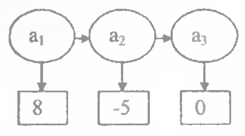

**Математическая структура** S=(M1,…,Mk; p1,…,ps) есть одно или несколько множеств М1,…,Мк, элементы которых находятся в некоторых отношениях р1,…,ps.

- М1,…,Мк – базисные множества структуры.
- Каждое отношение pi есть двоичная функция, аргументами которой являются элементы базисного множества.
- Если аргументы функции находятся в отношении, то значение pi = ИСТИНА.

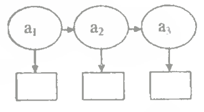

**Структура данных** - модель данных в виде математической структуры.

Примеры:

- множество операндов и операций и порядок их записи (арифметическое выражение)
- множество узлов детали и порядок их соединения (чертеж)
- множество людей и родственные связи между ними (генеалогическое дерево)
- множество населенных пунктов и пути сообщения (карта).

# 2. Разработка общего представления линейного списка для обеспечения списковой структуры хранения.

Значения представлены в виде объектов классов, являющихся производными из одного общего базового класса.

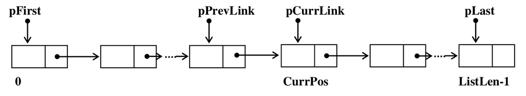

В поле значения звена списка размещается указатель на объект значение.

- pFirst – указатель на первое звено списка
- pLast – указатель на последнее звено списка
- pCurrLink – указатель на текущее звено списка
- pPrevLink – указатель на звено, предшествующее текущему
- CurrPos – номер текущего звена
- ListLen – количество звеньев в списке

Для **повышения общности** схемы реализации будем использовать вместо величины NULL константу pStop для фиксации ситуаций, в которых указатель не содержит адрес какого-либо звена списка.

Информационные методы:

- IsEmpty – проверить, не является ли список пустым
- GetListLength – получить количество звеньев списка

Методы доступа к значениям в списке:

- GetDatValue – получить указатель на значение из звена списка
- обращение возможно только к первому (FIRST), текущему (CURRENT) или последнему звеньям списка (LAST)
- желаемый вариант доступа задается через параметр метода

Методы навигации по списку (итератор):

- Reset – установить текущую позицию на первое звено
- GoNext – переместить текущую позицию на звено вправо
- IsListEnded – проверка завершения списка
- под ситуацией завершения списка понимается состояние после применения GoNext для текущей позиции, установленной на последнем звене списка, т.е. когда pPrevLink=pLast, pCurrLink=pStop
- GetCurrentPos – получить номер текущего звена, SetCurrentPos – установить текущую позицию на звено с заданным номером

Вставка звеньев:

- InsFirst – вставить звено перед первым звеном списка
- InsLast – вставить звено после последнего звена
- InsCurrent – вставить звено перед текущим звеном списка
- При выполнении операций вставки звеньев следует учитывать, что список может быть пустым
- После выполнения вставки необходимо обеспечить корректность значений указателей первого, текущего и последнего звеньев списка
- При корректировке указателей следует учитывать возможность различного положения текущей позиции списка
- текущая позиция является первым звеном (pCurrLink=pFirst)
- текущая позиция является вторым звеном (pPrevLink=pFirst)
- текущая позиция находится внутри списка
- текущая позиция является последним звеном (pCurrLink=pLast)
- текущая позиция выходит за пределы списка (pPrevLink=pLast)

Удаление звеньев:

- DelFirst – удалить первое звено списка
- DelCurrent – удалить текущее звено
- DelList – удалить список